# Single cell RNA-seq of cells labeled with AAV1_P5

## Figure 3f - Differential expression of eYFP+ vs. eYFP- cells

Mouse genes associated with GO-term GO:0009615 (response to virus)

```r
viral_resp_genes <- c('Cnot7', 'Ccl19', 'Tlr8', 'Polr3f', 'Rnasel', 'G3bp1', 'Trex1', 'Arf1', 'Gm13271', 'Htra1', 'Nlrc5', 'Src', 'Ifnlr1', 'Mill2', 'Atg7', 'Tkfc', 'Ddx58', 'Cyp1a1', 'Ifi27l2a', 'Ifi27l2b', 'Oas1g', 'Acta2', 'Aimp1', 'Ifna5', 'Il12b', 'Ifitm1', 'Exosc4', 'Il23a', 'Crcp', 'Bst2', 'Ifna16', 'Ddx41', 'Ifit1', 'Oasl2', 'Ifna12', 'Pqbp1', 'Slfn8', 'Ifngr1', 'Irf7', 'Ifit1bl1', 'Serinc5', 'Gm13290', 'Nop53', 'Rtp4', 'Mapk11', 'Riok3', 'Trim5', 'Rrp1b', 'Cxcl9', 'Tlr7', 'Ufd1', 'Skp2', 'Rsad2', 'Zmynd11', 'Gpam', 'Gli2', 'Lgals8', 'Dhx58', 'Elmod2', 'Trim6', 'Unc13d', 'Gm13276', 'Pycard', 'Gm13278', 'Irf5', 'Ticam2', 'Il33', 'Gtf2f1', 'Ifnl3', 'Pcbp2', 'Nlrp3', 'Mul1', 'Xpr1', 'Tbk1', 'Gm49380', 'Trim25', 'Fadd', 'Dtx3l', 'Gm13288', 'Polr3g', 'Trim38', 'Oas1b', 'Trim12c', 'Ifnar1', 'Eif2ak2', 'Gbp4', 'Becn1', 'Hyal3', 'Ppm1b', 'Oas2', 'Sting1', 'Ticam1', 'Lgals9', 'Tspan32', 'Tbx21', 'Ddx60', 'Dhx36', 'Rnf135', 'Mavs', 'Eif2ak4', 'Agbl5', 'Oas1e', 'Trim30a', 'Apobec3', 'Exosc5', 'Ifna9', 'Cd86', 'Il23r', 'Oas3', 'Mov10', 'Itch', 'Vwce', 'Chrm2', 'Stat1', 'Irf2', 'Sec14l1', 'Polr3c', 'Fv1', 'Rps15a', 'Trim30c', 'Cd207', 'Rnf26', 'Prf1', 'Tlr3', 'Ifnk', 'Ifnz', 'Xcl1', 'Traf3ip1', 'Oprk1', 'Gm13289', 'Agbl4', 'Gsdme', 'Ercc6', 'Ifna11', 'Ikbke', 'Uri1', 'Ddx3x', 'Nlrx1', 'Hyal1', 'Isg20', 'Bnip3', 'Ttc4', 'Ifngr2', 'Clu', 'Zmpste24', 'Ifna4', 'Cgas', 'Trim44', 'Gbf1', 'Spon2', 'Cxadr', 'Bcl2', 'Lcn2', 'Ivns1abp', 'Cd40', 'Treml4', 'Irf3', 'Mx2', 'Ap1s1', 'Duox2', 'Tlr13', 'Aicda', 'Il12rb1', 'Batf3', 'Traf3', 'Fgl2', 'Ifna13', 'Traf3ip2', 'Cfl1', 'Cd37', 'Gm13287', 'Ifna6', 'Parp9', 'Klra8', 'Il4', 'Pum2', 'Ddit4', 'Ifnab', 'Oas1f', 'Oas1a', 'Ifit3b', 'Zbp1', 'Stmn1', 'Bcl2l1', 'Setd2', 'Irak3', 'Dclk1', 'Trim12a', 'Gm13279', 'Polr3k', 'Irgm2', 'Map3k14', 'Crebzf', 'Gm13275', 'Gm45717', 'Rnase6', 'Bcl3', 'Tspan6', 'Cxcl10', 'Gm13285', 'Aim2', 'Trim11', 'Ptprc', 'Abcc9', 'Lsm14a', 'Tnfsf4', 'Ccl5', 'Ifitm6', 'Chuk', 'Tgtp1', 'Itgax', 'Ifitm2', 'Mir29b-1', 'Zdhhc1', 'Adar', 'Mmp12', 'Shfl', 'Rnf125', 'Tgtp2', 'Polr3e', 'Ankrd17', 'Card9', 'Cdk6', 'Plscr1', 'Ifng', 'Penk', 'Il2ra', 'Tarbp2', 'Nploc4', 'Irf1', 'Ilf3', 'Apob', 'Mst1r', 'Serinc3', 'Abcf3', 'Gpatch3', 'Zcchc3', 'Ifne', 'Isg15', 'Polr3b', 'F2rl1', 'Ifit1bl2', 'Myd88', 'Usp15', 'Ddx17', 'Stat2', 'Samhd1', 'Ncbp3', 'Gm13277', 'Slfn9', 'Tagap', 'Ifnb1', 'Zc3hav1', 'Polr3h', 'Ccdc130', 'Hspb1', 'Trim30d', 'Il1b', 'Hnrnpul1', 'Ptpn22', 'Tlr9', 'Sin3a', 'Mapk14', 'C1qbp', 'Ddx21', 'Il15', 'Rnf216', 'Nt5c3', 'Ddx1', 'Gm13272', 'Oasl1', 'Odc1', 'Selenok', 'Fmr1', 'Ifna7', 'Eef1g', 'Trim15', 'Ifna2', 'Pml', 'Bnip3l', 'Ifit3', 'Il12a', 'Oas1c', 'Cct5', 'Nlrp9b', 'Ifitm3', 'Hyal2', 'Ilrun', 'Gata3', 'Spn', 'Il27', 'Zc3h12a', 'Ifnar2', 'Ifitm7', 'Aen', 'Polr3d', 'Ifna14', 'Oas1h', 'Foxp3', 'Tnf', 'Ifih1', 'Wdfy4', 'Gm13283', 'Ifna15', 'Ifna1', 'Ifnl2', 'Cd8a', 'Pum1', 'Ifit2', 'Il6', 'Apobec1', 'Trim30b', 'Kcnj8', 'Oas1d')

# convert gene symbols to ensembl gene IDs
viral_resp_genes_ensg <- symbol2ensg[viral_resp_genes]

# list of transgenes (in order to remove them from the differential expression [DE] analysis)
transgenes <- c("AmpR_AAV_id.1", "Cre_AAV_id.1", "AmpR_genomic_id.1", "ERT2_genomic_id.1", "EYFP_id.1", "NeoR_KanR_id.1")
# list of lineage cell types (to exclude off-target cells from the DE analysis)
lineage_ct <- c("qNSC", "aNSC", "TAP", "ENB", "LNB")
```

Make pseudobulk samples, grouped by cell type

```r
pbulk_id <- metadata %>%
  filter(celltype %in% lineage_ct) %>%
  mutate(
    transduction = if_else(eYFP_counts > 0, "T", "NT"),
    batch = str_extract(batch, "\\d"),
    pbulk = as.character(glue::glue("{celltype}_{transduction}_{batch}"))) %>%
  dplyr::select(bc=barcode, i=pbulk)

pbulk_groups <- pbulk_id$i %>% unique() %>% sort()

pseudobulk <- sapply(pbulk_groups, function(.x) {
  barcodes <- filter(pbulk_id, i == .x)$bc
  sparseMatrixStats::colSums2(raw_counts[barcodes, ])
}) %>%
  magrittr::set_rownames(colnames(raw_counts))

head(pseudobulk)
```

```
##                       aNSC_NT_1 aNSC_NT_2 aNSC_T_1 aNSC_T_2 ENB_NT_1 ENB_NT_2
## ENSMUSG00000026535.9          0         0        0        4        0        0
## ENSMUSG00000026315.13         0         0        2        1        0        0
## ENSMUSG00000000817.10         0         0        0        0        0        1
## ENSMUSG00000063558.4          1         8        2        9        0        0
## ENSMUSG00000001138.13        25       236       70      266        4       55
## ENSMUSG00000001143.13        10       202       59      241       10       86
##                       ENB_T_1 ENB_T_2 LNB_NT_1 LNB_NT_2 LNB_T_1 LNB_T_2
## ENSMUSG00000026535.9        0       0        0        0       0       0
## ENSMUSG00000026315.13       0       1        0        0       0       0
## ENSMUSG00000000817.10       0       0        0        0       1       0
## ENSMUSG00000063558.4        2       3        1        3       3       5
## ENSMUSG00000001138.13      44     125       32       83      80     166
## ENSMUSG00000001143.13      61     260       51       92      89     255
##                       qNSC_NT_1 qNSC_NT_2 qNSC_T_1 qNSC_T_2 TAP_NT_1 TAP_NT_2
## ENSMUSG00000026535.9          0         0        0        0        0        1
## ENSMUSG00000026315.13         0         0        0        0        0        1
## ENSMUSG00000000817.10         0         0        0        0        0        0
## ENSMUSG00000063558.4         12       179        2       18        0        2
## ENSMUSG00000001138.13         8       119        3       10       13       39
## ENSMUSG00000001143.13        11        81        2       11        0       71
##                       TAP_T_1 TAP_T_2
## ENSMUSG00000026535.9        0       1
## ENSMUSG00000026315.13       0       1
## ENSMUSG00000000817.10       0       0
## ENSMUSG00000063558.4        1       7
## ENSMUSG00000001138.13      33     110
## ENSMUSG00000001143.13      40     195
```

Run DESeq2 on pseudobulk samples. We're using the likelihood ratio test (LRT) to test the full model `~ batch + cluster + condition` against the reduced model `~ batch + cluster`. In this case, `condition` is a boolean variable indicating whether cells express eYFP or not.

```r
condition <- factor(str_extract(colnames(pseudobulk), "_N?T_"))
col_data <- DataFrame(
  condition = condition,
  batch = factor(str_extract(colnames(pseudobulk), "\\d")),
  cluster = factor(str_extract(colnames(pseudobulk), "[A-Za-z]+"))
) %>% set_rownames(colnames(pseudobulk))

dds <- DESeqDataSetFromMatrix(
  pseudobulk[!(colnames(raw_counts) %in% transgenes), ],
  col_data,
  ~ batch + cluster + condition
)
## converting counts to integer mode

dds <- DESeq(dds, test="LRT", reduced = ~ batch + cluster)
## estimating size factors
## estimating dispersions
## gene-wise dispersion estimates
## mean-dispersion relationship
## final dispersion estimates
## fitting model and testing
res <- results(dds) %>%
  as_tibble(rownames = "gene")
```

There are the following 18 differentially expressed genes:

```r
res %>% filter(padj <= 0.05) %>% arrange(padj) %>% mutate(symbol = ensg2symbol[gene]) %>% dplyr::select(-stat)
```

```
## # A tibble: 18 x 7
##    gene             baseMean log2FoldChange  lfcSE     pvalue    padj symbol
##    <chr>               <dbl>          <dbl>  <dbl>      <dbl>   <dbl> <chr>
##  1 ENSMUSG00000029…    570.          -1.12  0.211     1.00e-7 5.48e-4 Sparcl1
##  2 ENSMUSG00000069…     81.3         -0.828 0.169     9.69e-7 2.66e-3 Nr2f1
##  3 ENSMUSG00000087…    118.          -0.636 0.140     5.84e-6 1.07e-2 A830082K1…
##  4 ENSMUSG00000020…    196.          -0.824 0.183     8.32e-6 1.14e-2 Ntsr2
##  5 ENSMUSG00000075…    161.          -0.601 0.137     1.25e-5 1.37e-2 Fjx1
##  6 ENSMUSG00000047…     62.7         -0.956 0.222     2.09e-5 1.91e-2 Cdh19
##  7 ENSMUSG00000038…    481.          -0.353 0.0854    3.82e-5 2.62e-2 Trps1
##  8 ENSMUSG00000051…     40.7         -0.743 0.179     3.52e-5 2.62e-2 Ncald
##  9 ENSMUSG00000037…    453.          -0.431 0.105     4.51e-5 2.75e-2 Adgrl3
## 10 ENSMUSG00000023…    209.          -0.989 0.244     6.74e-5 3.20e-2 Pla2g7
## 11 ENSMUSG00000028…    876.          -0.476 0.119     6.50e-5 3.20e-2 Plpp3
## 12 ENSMUSG00000032…    683.          -0.345 0.0866    7.01e-5 3.20e-2 Rora
## 13 ENSMUSG00000069…    294.          -0.627 0.161     1.16e-4 4.75e-2 Nkain2
## 14 ENSMUSG00000112…    107.          -0.865 0.225     1.21e-4 4.75e-2 Rmst
## 15 ENSMUSG00000017…    115.          -0.489 0.128     1.53e-4 4.85e-2 Abr
## 16 ENSMUSG00000071…     94.5         -0.545 0.143     1.42e-4 4.85e-2 Zhx2
## 17 ENSMUSG00000022…     42.9         -1.70  0.444     1.59e-4 4.85e-2 Shisa9
## 18 ENSMUSG00000053…    378.          -0.765 0.200     1.48e-4 4.85e-2 Ptprt
```

Plot the results (Fig 3f)

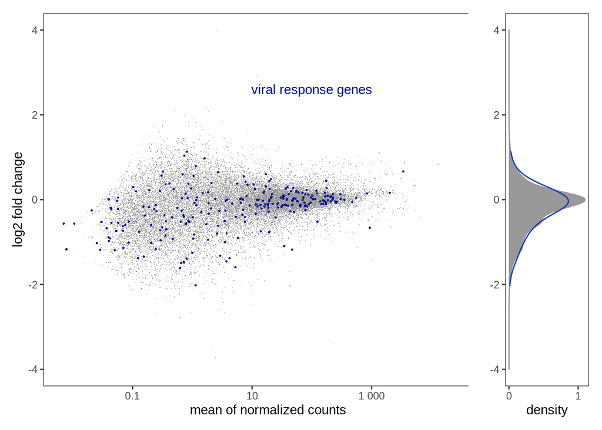

```r
p_ma <- res %>%
  mutate(is_viral = gene %in% viral_resp_genes_ensg) %>%
  arrange(is_viral) %>%
  ggplot(aes(x = baseMean, y = log2FoldChange, color = is_viral, size = is_viral)) +
  geom_point(stroke=0) +
  scale_x_log10(label=scales::label_number(drop0trailing=T)) +
  scale_color_manual(values = c("TRUE"="#051094", "FALSE"="gray60")) +
  scale_size_manual(values = c("TRUE"=.9, "FALSE"=.33)) +
  labs(x = "mean of normalized counts", y = "log2 fold change") +
  theme(legend.position = "none") +
  annotate("text", x = 100, y = 2.6, label = "viral response genes", color = "#051094")

p_dens <- res %>%
  filter(!(gene %in% transgenes)) %>%
  ggplot(aes(y = log2FoldChange)) +
  geom_density(color = "gray60", fill = "gray60", adjust = 2) +
  geom_density(data = filter(res, gene %in% viral_resp_genes_ensg),
               mapping = aes(y = log2FoldChange),
               color = "#1338BE", fill = NA, adjust = 2,
               inherit.aes = F, trim = T) +
  scale_x_continuous(breaks = c(0, 1)) +
  labs(x = "density", y = "")

p_ma + p_dens &
  ylim(-4, 4) &
  plot_layout(widths = c(5, 1))
## Warning: Transformation introduced infinite values in continuous x-axis
## Warning: Removed 8105 rows containing missing values (geom_point).
## Warning: Removed 8105 rows containing non-finite values (stat_density).
## Warning: Removed 52 rows containing non-finite values (stat_density).
```

# Supplementary Figure S4k - Differential expression of eYFP+ vs. eYFP-/NeoR+ cells

Here, we consider eYFP+ cells as transduced and eYFP-/NeoR+ as non-transduced.  
In this comparison we have very few cells because NeoR+ cells are quite rare. Hence we cannot include cell type as a covariate.

```r
# get the indices of cells of the four different pseudobulk groups
transduced_bc_1 <- metadata %>%
  filter(eYFP_counts > 0 & batch == "WT1" & celltype %in% lineage_ct) %>%
  pull(barcode)
transduced_bc_2 <- metadata %>%
  filter(eYFP_counts > 0 & batch == "WT2" & celltype %in% lineage_ct) %>%
  pull(barcode)
not_transduced_bc_1 <- metadata %>%
  filter(eYFP_counts == 0 & NeoR_counts > 0 & batch == "WT1" & celltype %in% lineage_ct) %>%
  pull(barcode)
not_transduced_bc_2 <- metadata %>%
  filter(eYFP_counts == 0 & NeoR_counts > 0 & batch == "WT2" & celltype %in% lineage_ct) %>%
  pull(barcode)

# aggregate single cell counts to pseudobulk
pseudobulk <- cbind(
  sparseMatrixStats::colSums2(raw_counts[transduced_bc_1, ]),
  sparseMatrixStats::colSums2(raw_counts[transduced_bc_2, ]),
  sparseMatrixStats::colSums2(raw_counts[not_transduced_bc_1, ]),
  sparseMatrixStats::colSums2(raw_counts[not_transduced_bc_2, ])
) %>%
  magrittr::set_rownames(colnames(raw_counts)) %>%
  magrittr::set_colnames(c("sample1_transduced", "sample2_transduced", "sample1_rest", "sample2_rest"))

# run DESeq2
condition <- factor(c("transduced", "transduced", "rest", "rest"))
dds <- DESeqDataSetFromMatrix(
  pseudobulk,
  DataFrame(condition),
  ~ condition
)
## converting counts to integer mode

dds <- DESeq(dds)
## estimating size factors
## estimating dispersions
## gene-wise dispersion estimates
## mean-dispersion relationship
## final dispersion estimates
## fitting model and testing
res <- results(dds) %>%
  as_tibble(rownames = "gene")
```

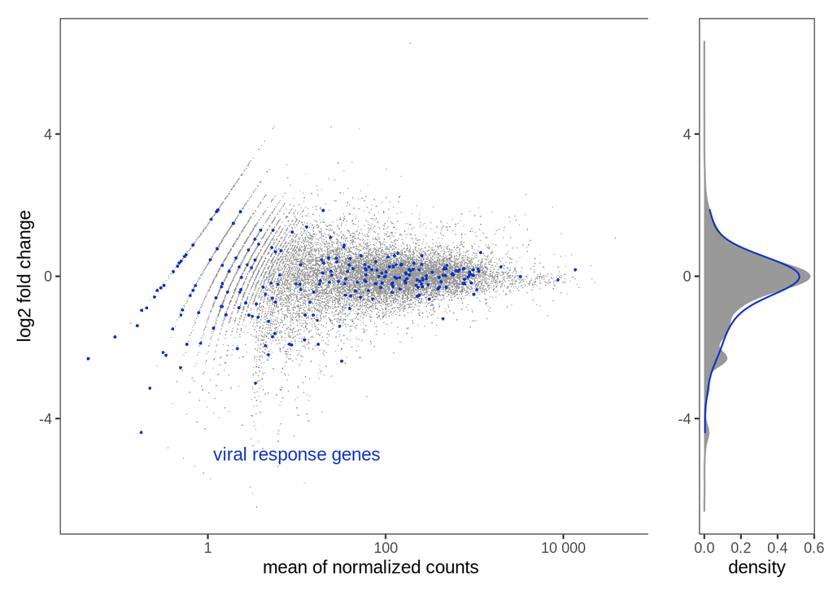

```r
sig_res <- res %>% filter(padj <= 0.05) %>%
  mutate(symbol = ensg2symbol[gene])

p_ma <- res %>%
  filter(!(gene %in% transgenes)) %>%
  mutate(is_viral = gene %in% viral_resp_genes_ensg) %>%
  arrange(is_viral) %>%
  ggplot(aes(x = baseMean, y = log2FoldChange, color = is_viral, size = is_viral)) +
  geom_point(stroke=0) +
  scale_x_log10(label=scales::label_number(drop0trailing=T)) +
  scale_color_manual(values = c("TRUE"="#1338BE", "FALSE"="gray60")) +
  scale_size_manual(values = c("TRUE"=.9, "FALSE"=.33)) +
  labs(x = "mean of normalized counts", y = "log2 fold change") +
  theme(legend.position = "none") +
  annotate("text", x = 10, y = -5, label = "viral response genes", color = "#1338BE")

p_dens <- res %>%
  filter(!(gene %in% transgenes)) %>%
  ggplot(aes(y = log2FoldChange)) +
  geom_density(color = "gray60", fill = "gray60", adjust = 2) +
  geom_density(data = filter(res, gene %in% viral_resp_genes_ensg),
               mapping = aes(y = log2FoldChange),
               color = "#1338BE", fill = NA, adjust = 2,
               inherit.aes = F, trim = T) +
  labs(y = "")

p_ma + p_dens &
  ylim(-6.6, 6.6) &
  plot_layout(widths = c(5, 1))
## Warning: Transformation introduced infinite values in continuous x-axis
## Warning: Removed 8660 rows containing missing values (geom_point).
## Warning: Removed 8660 rows containing non-finite values (stat_density).
## Warning: Removed 56 rows containing non-finite values (stat_density).
```

High log2foldChange = higher expression in transduced cells  
Low log2foldChange = lower expression in transduced cells